# Cricket Data Analysis

# Data Processing - Data_Processing.R

## Preprocessing

Library Loading

```r
library(cricketdata)
library(dplyr)
library(pROC)
library(caret)
library(glmnet)
library(ggplot2)
library(stats)
library(knitr)
library(lsr)
library(datasets)
batting_data <- read.csv("../data/battinginningdata.csv")  # Gets from working directory to batting innings data
bowling_data <- read.csv("../data/bowlinginningdata.csv")  # Gets from working directory to bowling innings data
match_data_file_cricinfo = read.csv("../data/MatchData-Cricinfo.csv") # Gets match result data from Cricinfo results file
```

Create Country Acronym Mapping - 12 Test-playing nations

```r
country_acronyms <- c(
  "Australia" = "AUS",
  "India" = "IND",
  "South Africa" = "RSA",
  "England" = "ENG",
  "New Zealand" = "NZL",
  "West Indies" = "WI",
  "Pakistan" = "PAK",
  "Sri Lanka" = "SL",
  "Afghanistan" = "AFG",
  "Bangladesh" = "BAN",
  "Ireland" = "IRE",
  "Zimbabwe" = "ZIM"
  # Add more as needed
)
countries = c("Australia", "India", "South Africa", "England", "New Zealand", "West Indies", "Pakistan", "Sri Lanka", "Afghanistan", "Bangladesh", "Ireland", "Zimbabwe")
```

Remove countries not in country list, change BAN to Bangladesh

```r
batting_data <- batting_data %>% mutate(Country = ifelse(Country == "BAN", "Bangladesh", Country))
bowling_data <- bowling_data %>% mutate(Country = ifelse(Country == "BAN", "Bangladesh", Country))
match_data_file_cricinfo <- match_data_file_cricinfo %>% filter(Team.1 %in% countries & Team.2 %in% countries & Winner %in% countries)
batting_data <- batting_data %>% filter(Country %in% countries & Opposition %in% countries)
bowling_data <- bowling_data %>% filter(Country %in% countries & Opposition %in% countries)
```

Replace with acronym

```r
match_data_file_cricinfo$Team.1 <- country_acronyms[match_data_file_cricinfo$Team.1]
match_data_file_cricinfo$Team.2 <- country_acronyms[match_data_file_cricinfo$Team.2]
match_data_file_cricinfo$Winner <- country_acronyms[match_data_file_cricinfo$Winner]
batting_data$Country <- country_acronyms[batting_data$Country]
batting_data$Opposition <- country_acronyms[batting_data$Opposition]
bowling_data$Country <- country_acronyms[bowling_data$Country]
bowling_data$Opposition <- country_acronyms[bowling_data$Opposition]


match_data_file_cricinfo$Date <- as.Date.character(match_data_file_cricinfo$Match.Date, format = "%b %d, %Y")
batting_data$Date <- as.Date(batting_data$Date)
bowling_data$Date <- as.Date(bowling_data$Date)

batting_data$Team = batting_data$Country
bowling_data$Team = bowling_data$Country
batting_data$Opponent = batting_data$Opposition
bowling_data$Opponent = bowling_data$Opposition
```

Create a combined Team column in match_data_file_cricinfo

```r
match_data_file_cricinfo <- match_data_file_cricinfo %>%
  mutate(Team = ifelse(Team.1 < Team.2, paste(Team.1, Team.2), paste(Team.2, Team.1)))
```

Create a combined Team column in batting_data and bowling_data

```r
batting_data <- batting_data %>%
  mutate(Team = ifelse(Country < Opposition, paste(Country, Opposition), paste(Opposition, Country)))
bowling_data <- bowling_data %>%
  mutate(Team = ifelse(Country < Opposition, paste(Country, Opposition), paste(Opposition, Country)))
```

Print some info for debugging

```r
print("Unique Dates in match_data_file_cricinfo:")
print(unique(match_data_file_cricinfo$Date))
print("Unique Dates in batting_data:")
print(unique(batting_data$Date))
print("Unique Dates in bowling_data:")
print(unique(bowling_data$Date))

print("Unique Teams in match_data_file_cricinfo:")
print(unique(match_data_file_cricinfo$Team))
print("Unique Teams in batting_data:")
print(unique(batting_data$Team))
print("Unique Teams in bowling_data:")
print(unique(bowling_data$Team))
```

Join data by match

```r
batting_data <- left_join(batting_data, dplyr::select(match_data_file_cricinfo, ID, Date, Team), by = c("Date", "Team"))
bowling_data <- left_join(bowling_data, dplyr::select(match_data_file_cricinfo, ID, Date, Team), by = c("Date", "Team"))
```

Compute Batting Impact

```r
batting_data <- batting_data %>%
  mutate(OutPenalty = ifelse(NotOut == FALSE, 0.5, 0),
         BattingImpact = Runs * 0.125 + ((StrikeRate - 130) * 0.025) + (Fours * 0.3) + (Sixes * 0.5) - OutPenalty)
```

Compute Bowling Impact

```r
bowling_data <- bowling_data %>%
  mutate(BowlingImpact = (Wickets * 3.25) + (Maidens * 3) - (Economy - 7.4) * 0.5)
```

## Distribution Comparison - Verify Batting and Bowling Impact are Similar

Aggregate Batting and Bowling Impact by Player and Country, Plot Distribution

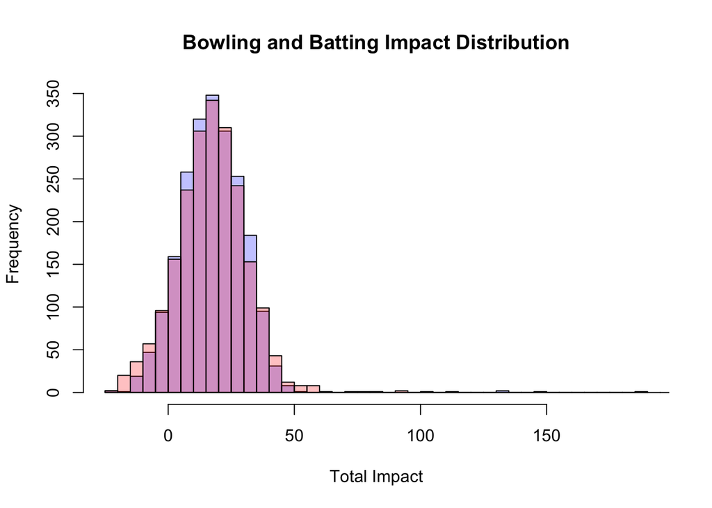

```r
batting_impact <- batting_data %>%
  group_by(ID, Country) %>%
  summarise(TotalBattingImpact = sum(BattingImpact, na.rm = TRUE)) %>%
  ungroup()

bowling_impact <- bowling_data %>%
  group_by(ID, Country) %>%
  summarise(TotalBowlingImpact = sum(BowlingImpact, na.rm = TRUE)) %>%
  ungroup()

hist(bowling_impact$TotalBowlingImpact, breaks = 50, main = "Bowling and Batting Impact Distribution", xlab = "Total Impact", col = rgb(0,0,1,1/4))
hist(batting_impact$TotalBattingImpact, breaks = 50, main = "Batting Impact Distribution", xlab = "Total Batting Impact", col = rgb(1,0,0,1/4), add = TRUE)
```

Kolmogorov-Smirnov Test with p > 0.05 verifies that we cannot reject the null hypothesis that the two distributions are the same, with almost 0 evidence (p = 0.37)

```r
ks.test(bowling_impact$TotalBowlingImpact, batting_impact$TotalBattingImpact)
```

```
##
##  Asymptotic two-sample Kolmogorov-Smirnov test
##
## data:  bowling_impact$TotalBowlingImpact and batting_impact$TotalBattingImpact
## D = 0.028116, p-value = 0.3678
## alternative hypothesis: two-sided
```

QQ Plot to visually compare the distributions

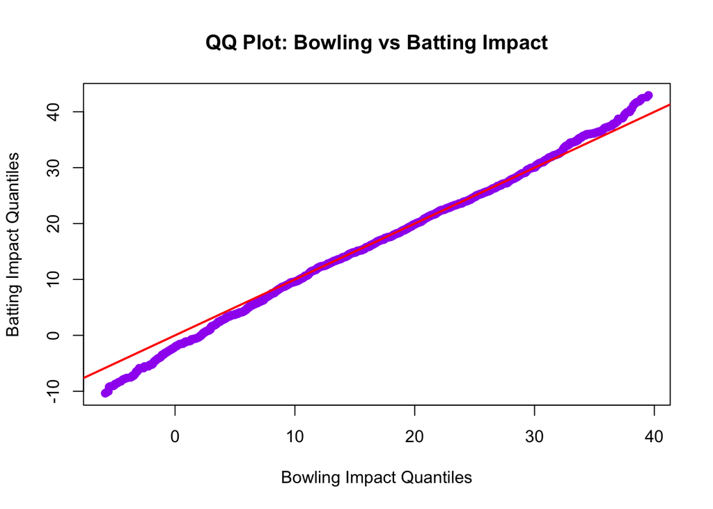

```r
qqplot(
  quantile(bowling_impact$TotalBowlingImpact, probs = seq(0.025, 0.975, length.out = 1000)),
  quantile(batting_impact$TotalBattingImpact, probs = seq(0.025, 0.975, length.out = 1000)),
  xlab = "Bowling Impact Quantiles",
  ylab = "Batting Impact Quantiles",
  main = "QQ Plot: Bowling vs Batting Impact",
  pch = 19, col = "purple"
)
abline(0, 1, col = "red", lwd = 2)  # line of equality
```

Calculate Cohen’s d to measure that the effect size is minimal (d < 0.1)

```r
cohensD(batting_impact$TotalBattingImpact, bowling_impact$TotalBowlingImpact)
```

```
## [1] 0.02783777
```

```r
bowling_impact$TotalBowlingImpact = (bowling_impact$TotalBowlingImpact)
batting_impact$TotalBattingImpact = (batting_impact$TotalBattingImpact)
```

Merge Batting & Bowling Impact

```r
team_impact <- batting_impact %>%
  full_join(bowling_impact, by = c("ID", "Country")) %>%
  mutate(TotalImpact = TotalBattingImpact + TotalBowlingImpact)
```

## Merge with Match Data and Measure Correlation with Match Outcome

Don’t run commented line below on first run, but can be done afterward to reset columns

```r
#match_data_file_cricinfo[, 10:16] <- list(NULL)
match_data_file_cricinfo <- match_data_file_cricinfo %>%
  left_join(team_impact, by = c("ID" = "ID", "Team.1" = "Country")) %>%
  rename(Impact_Team1 = TotalImpact) %>%
  left_join(team_impact, by = c("ID" = "ID", "Team.2" = "Country")) %>%
  rename(Impact_Team2 = TotalImpact)
```

Compute Impact Difference & Outcome Variable

```r
match_data_file_cricinfo <- match_data_file_cricinfo %>%
  mutate(Impact_Diff = Impact_Team1 - Impact_Team2,
         Winner_Team1 = ifelse(Winner == Team.1, 1, 0))
```

Print the final correlation and R-squared value

```r
print(paste("Final correlation: ", cor(match_data_file_cricinfo$Impact_Diff, match_data_file_cricinfo$Winner_Team1, use = "complete.obs")))
```

```
## [1] "Final correlation:  0.774106530488118"
```

```r
rsquared = cor(match_data_file_cricinfo$Impact_Diff, match_data_file_cricinfo$Winner_Team1, use = "complete.obs")^2
cor.test(match_data_file_cricinfo$Impact_Diff, match_data_file_cricinfo$Winner_Team1, use = "complete.obs")
```

```
##
##  Pearson's product-moment correlation
##
## data:  match_data_file_cricinfo$Impact_Diff and match_data_file_cricinfo$Winner_Team1
## t = 39.793, df = 1059, p-value < 2.2e-16
## alternative hypothesis: true correlation is not equal to 0
## 95 percent confidence interval:
##  0.7488087 0.7971521
## sample estimates:
##       cor
## 0.7741065
```

```r
print(paste("Final R-squared: ", rsquared))
```

```
## [1] "Final R-squared:  0.599240920544352"
```

# Creating Player Rankings - Player_Rankings.R

## Summarize Impact by Player

Join batting and bowling data for player rankings

```r
player_data <- full_join(batting_data, bowling_data, by = c("Player", "ID", "Ground", "Country"))
```

Player Rankings based on Batting and Bowling ratings without making separate players one for batting and bowling

```r
player_rankings <- player_data %>%
  group_by(Player, Country) %>%
  summarise(
    CareerBatImpact = sum(BattingImpact, na.rm = TRUE),
    CareerBowlImpact = sum(BowlingImpact, na.rm = TRUE),
    MatchesPlayed = n()
  ) %>%
  mutate(TotalImpact = CareerBatImpact + CareerBowlImpact) %>%
  arrange(desc(TotalImpact))
```

Join player batting bowling data

```r
player_rankings_2 = data.frame()
```

Loop through the player rankings unique elements and get the higher of their bat bowl impacts to use in new dataframe

```r
for (player in unique(player_rankings$Player)){
  #if quote at the end of player name string, skip
  if(endsWith(player, " ")){
    next
  }

  person = player_rankings %>% filter(Player == paste(player, " ", sep = ""))
  person2 = player_rankings %>% filter(Player == player)
  # get which one of person and person2 has non zero batting impact and choose that
  if(person$CareerBowlImpact[1] == 0 & person2$CareerBowlImpact[1] == 0){
    #find which bat impact isn't 0
    if(person$CareerBatImpact[1] != 0){
      player_rankings_2 = rbind(player_rankings_2, person)
      next
    }
    else{
      player_rankings_2 = rbind(player_rankings_2, person2)
      next
    }
  }
  if(person$CareerBatImpact[1] == 0){
    #only bowling records
    person$CareerBatImpact[1] = person2$CareerBatImpact[1]
    player_rankings_2 = rbind(player_rankings_2, person)
  }
  else if(person2$CareerBowlImpact[1] == 0){
    #only batting records
    person2$CareerBowlImpact[1] = person$CareerBowlImpact[1]
    player_rankings_2 = rbind(player_rankings_2, person2)
  }
  else if(person$CareerBowlImpact[1] == 0){
    #only batting records
    person$CareerBowlImpact[1] = person2$CareerBowlImpact[1]
    player_rankings_2 = rbind(player_rankings_2, person)
  }
  else if(person2$CareerBatImpact[1] == 0){
    #only bowling records
    person2$CareerBatImpact[1] = person$CareerBatImpact[1]
    player_rankings_2 = rbind(player_rankings_2, person2)
  }

}
```

Correct naming issue

```r
rows <- which(player_rankings_2$Player == "Ihsanullah ")
player_rankings_2$CareerBowlImpact[rows] <- rev(player_rankings_2$CareerBowlImpact[rows])
```

## Player Comparison and Visualization

Descriptive Stats and create player tables

```r
player_rankings_2$TotalImpact = player_rankings_2$CareerBatImpact + player_rankings_2$CareerBowlImpact
player_rankings_2 = player_rankings_2 %>% arrange(desc(TotalImpact))
player_rankings_2$BatImpactperGame = player_rankings_2$CareerBatImpact / player_rankings_2$MatchesPlayed
player_rankings_2$BatImpactperGame_Z = (player_rankings_2$BatImpactperGame - mean(player_rankings_2$BatImpactperGame, na.rm = TRUE)) / sd(player_rankings_2$BatImpactperGame, na.rm = TRUE)
player_rankings_2$BowlImpactperGame = player_rankings_2$CareerBowlImpact / player_rankings_2$MatchesPlayed
player_rankings_2$BowlImpactperGame_Z = (player_rankings_2$BowlImpactperGame - mean(player_rankings_2$BowlImpactperGame, na.rm = TRUE)) / sd(player_rankings_2$BowlImpactperGame, na.rm = TRUE)
player_rankings_2$TotalImpactperGame = player_rankings_2$TotalImpact / player_rankings_2$MatchesPlayed
player_rankings_2$TotalImpactperGame_Z = player_rankings_2$BatImpactperGame_Z + player_rankings_2$BowlImpactperGame_Z
player_rankings_2 = player_rankings_2 %>% arrange(desc(MatchesPlayed)) #Model all matches
player_rankings_display = player_rankings_2 %>% filter(MatchesPlayed >= 20)
player_database = player_rankings_2 %>% filter(MatchesPlayed >= 5)
bowlimpactmedian = quantile(player_rankings_display$BowlImpactperGame, 5/11)
batimpactmedian = quantile(player_rankings_display$BatImpactperGame, 3.5/11)
player_rankings_display2 = player_rankings_display %>% dplyr::filter(BowlImpactperGame > bowlimpactmedian)
allrounderranking = player_rankings_display2 %>% dplyr::filter(BatImpactperGame > batimpactmedian)
allrounderranking = allrounderranking %>% arrange(desc(TotalImpactperGame))
(player_rankings_display)
```

| Player | Country | CareerBatImpact | CareerBowlImpact | MatchesPlayed | TotalImpact | BatImpactperGame | BatImpactperGame_Z | BowlImpactperGame | BowlImpactperGame_Z | TotalImpactperGame | TotalImpactperGame_Z |
| --- | --- | --- | --- | --- | --- | --- | --- | --- | --- | --- | --- |
| RG Sharma | IND | 599.65034854 | -10.8666667 | 153 | 588.783682 | 3.919283324 | 1.824425537 | -0.071023965 | -0.725368273 | 3.8482594 | 1.099057264 |
| JC Buttler | ENG | 572.19820736 | 0.0000000 | 132 | 572.198207 | 4.334834904 | 2.066500438 | 0.000000000 | -0.687008106 | 4.3348349 | 1.379492331 |
| Mahmudullah | BAN | 247.01392339 | 93.8416667 | 124 | 340.855590 | 1.992047769 | 0.701736135 | 0.756787634 | -0.278265796 | 2.7488354 | 0.423470339 |
| AU Rashid | ENG | -27.61056150 | 412.9297619 | 122 | 385.319200 | -0.226316078 | -0.590546780 | 3.384670180 | 1.141058111 | 3.1583541 | 0.550511331 |
| DA Miller | RSA | 382.27132547 | 0.0000000 | 122 | 382.271325 | 3.133371520 | 1.366601453 | 0.000000000 | -0.687008106 | 3.1333715 | 0.679593347 |
| GJ Maxwell | AUS | 451.04082083 | 97.0108974 | 120 | 548.051718 | 3.758673507 | 1.730864094 | 0.808424145 | -0.250376827 | 4.5670977 | 1.480487267 |
| V Kohli | IND | 608.06106199 | 4.3791667 | 119 | 612.440229 | 5.109756823 | 2.517922489 | 0.036799720 | -0.667132514 | 5.1465565 | 1.850789974 |
| Babar Azam | PAK | 530.36855757 | 0.0000000 | 119 | 530.368558 | 4.456878635 | 2.137595641 | 0.000000000 | -0.687008106 | 4.4568786 | 1.450587535 |
| TG Southee | NZL | 29.41153382 | 448.6684058 | 119 | 478.079940 | 0.247155746 | -0.314731093 | 3.770322737 | 1.349349725 | 4.0174785 | 1.034618632 |
| IS Sodhi | NZL | -23.10665931 | 400.4995106 | 119 | 377.392851 | -0.194173608 | -0.571822546 | 3.365542106 | 1.130727006 | 3.1713685 | 0.558904460 |

[output cut: 396 more lines]

Plot top 15 batsman by career bat impact

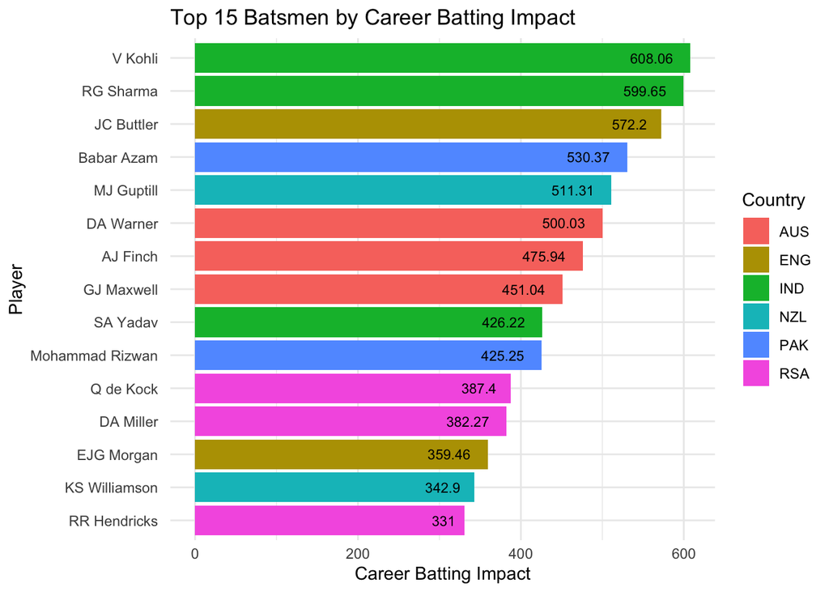

```r
par(mfrow = c(1, 1)) # Set up the plotting area to have one plot

library(ggplot2)
top_batsmen <- player_rankings_display %>%
  arrange(desc(CareerBatImpact)) %>%
  head(15)
ggplot(top_batsmen, aes(x = reorder(Player, CareerBatImpact), y = CareerBatImpact, fill = Country)) +
  geom_bar(stat = "identity") +
  coord_flip() +
  labs(title = "Top 15 Batsmen by Career Batting Impact",
       x = "Player",
       y = "Career Batting Impact") +
  theme_minimal() +
  geom_text(aes(label = round(CareerBatImpact, 2)), hjust = 1.4, color = "black", size = 3) # Add labels for clarity
```

Plot top 15 bowlers by career bowl impact

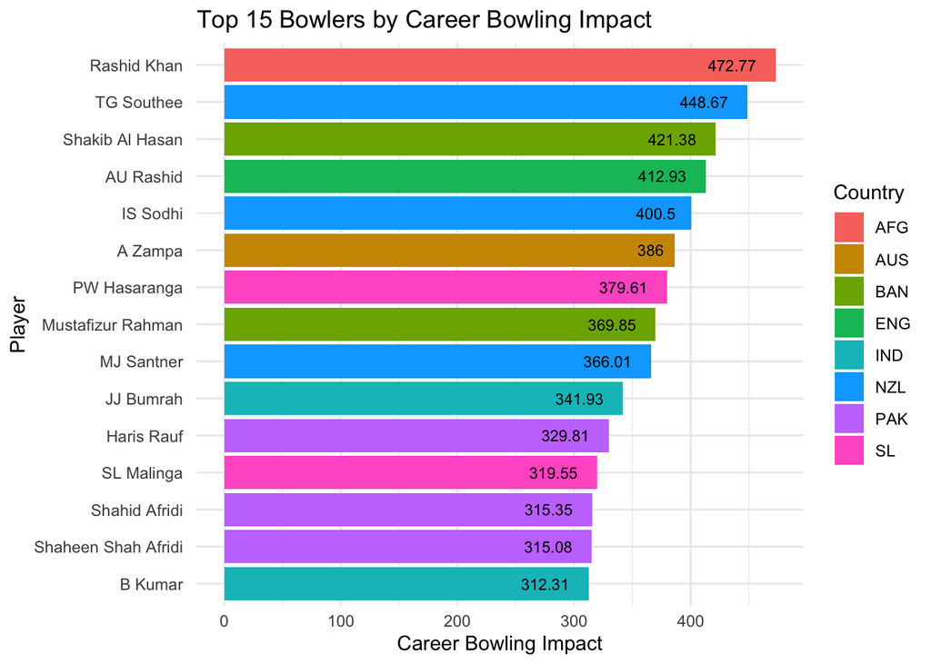

```r
top_bowlers <- player_rankings_display %>%
  arrange(desc(CareerBowlImpact)) %>%
  head(15)
ggplot(top_bowlers, aes(x = reorder(Player, CareerBowlImpact), y = CareerBowlImpact, fill = Country)) +
  geom_bar(stat = "identity") +
  coord_flip() +
  labs(title = "Top 15 Bowlers by Career Bowling Impact",
       x = "Player",
       y = "Career Bowling Impact") +
  theme_minimal() +
  geom_text(aes(label = round(CareerBowlImpact, 2)), hjust = 1.4, color = "black", size = 3) # Add labels for clarity
```

Plot top 15 all-rounders by total impact, partitioning the batting and bowling section

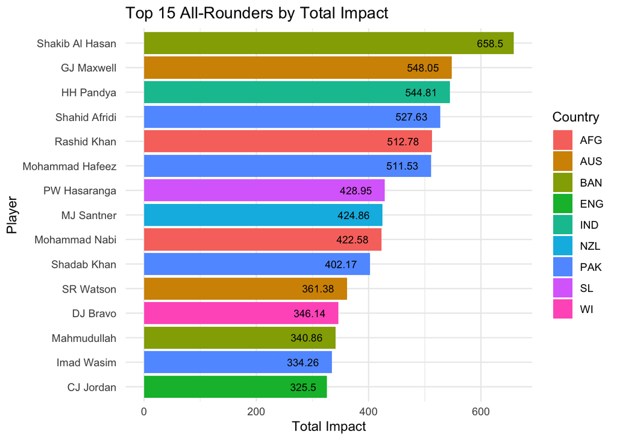

```r
top_allrounders <- allrounderranking %>%
  arrange(desc(TotalImpact)) %>%
  head(15)
ggplot(top_allrounders, aes(x = reorder(Player, TotalImpact), y = TotalImpact, fill = Country)) +
  geom_bar(stat = "identity") +
  coord_flip() +
  labs(title = "Top 15 All-Rounders by Total Impact",
       x = "Player",
       y = "Total Impact") +
  theme_minimal() +
  geom_text(aes(label = round(TotalImpact, 2)), hjust = 1.4, color = "black", size = 3) # Add labels for clarity
```

Plot top 15 all-rounders by Batting and Bowling Impact per Game

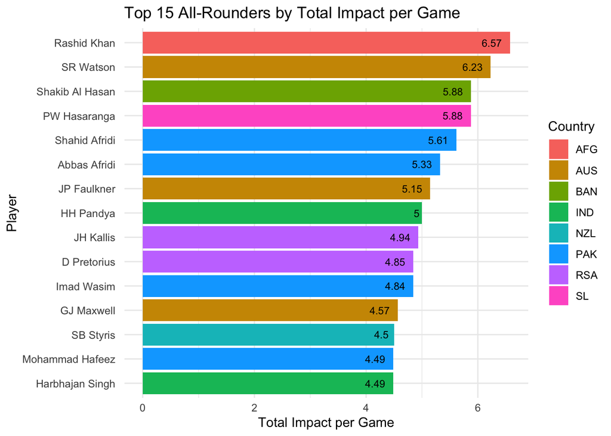

```r
top_allrounders_per_game <- allrounderranking %>%
  arrange(desc(TotalImpactperGame)) %>%
  head(15)
ggplot(top_allrounders_per_game, aes(x = reorder(Player, TotalImpactperGame), y = TotalImpactperGame, fill = Country)) +
  geom_bar(stat = "identity") +
  coord_flip() +
  labs(title = "Top 15 All-Rounders by Total Impact per Game",
       x = "Player",
       y = "Total Impact per Game") +
  theme_minimal() +
  geom_text(aes(label = round(TotalImpactperGame, 2)), hjust = 1.4, color = "black", size = 3) # Add labels for clarity
```

Plot top 15 Batsman by Batting Impact per Game

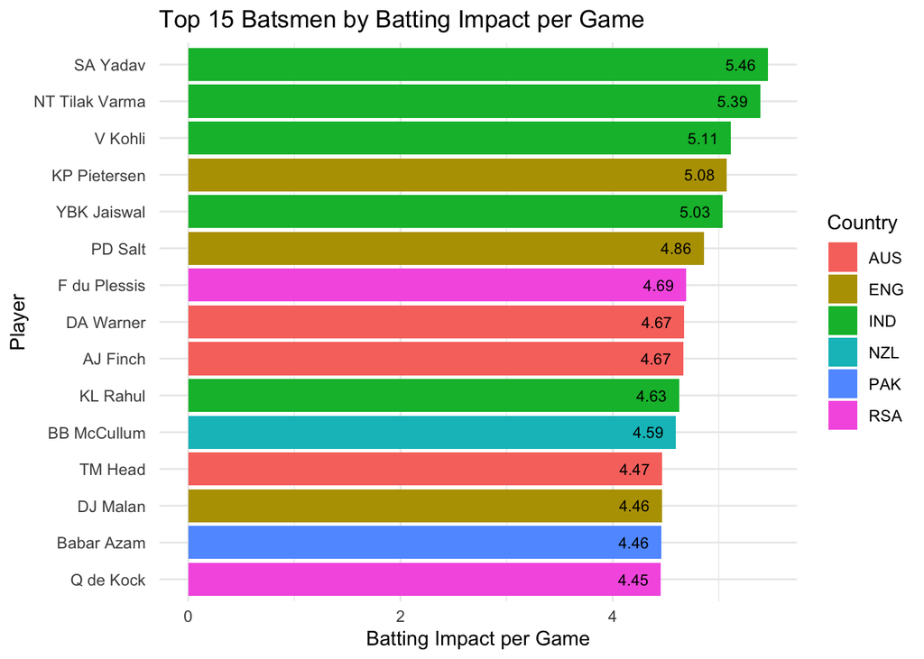

```r
top_batsmen_per_game <- player_rankings_display %>%
  arrange(desc(BatImpactperGame)) %>%
  head(15)
ggplot(top_batsmen_per_game, aes(x = reorder(Player, BatImpactperGame), y = BatImpactperGame, fill = Country)) +
  geom_bar(stat = "identity") +
  coord_flip() +
  labs(title = "Top 15 Batsmen by Batting Impact per Game",
       x = "Player",
       y = "Batting Impact per Game") +
  theme_minimal() +
  geom_text(aes(label = round(BatImpactperGame, 2)), hjust = 1.4, color = "black", size = 3) # Add labels for clarity
```

Plot top 15 Bowlers by Bowling Impact per Game

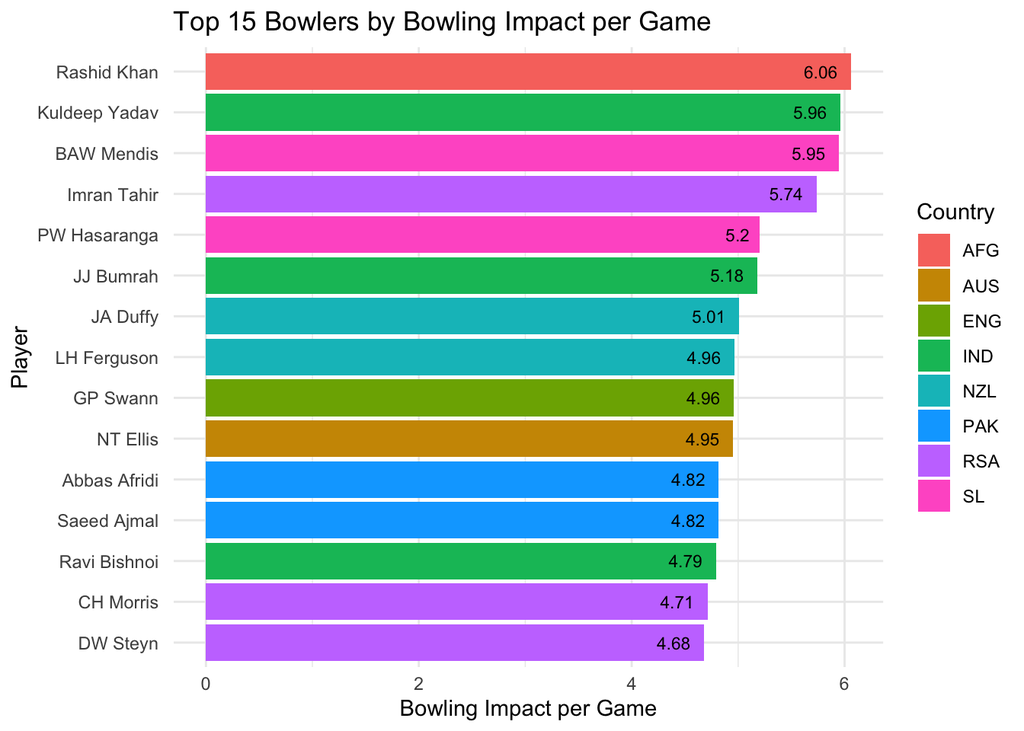

```r
top_bowlers_per_game <- player_rankings_display %>%
  arrange(desc(BowlImpactperGame)) %>%
  head(15)
ggplot(top_bowlers_per_game, aes(x = reorder(Player, BowlImpactperGame), y = BowlImpactperGame, fill = Country)) +
  geom_bar(stat = "identity") +
  coord_flip() +
  labs(title = "Top 15 Bowlers by Bowling Impact per Game",
       x = "Player",
       y = "Bowling Impact per Game") +
  theme_minimal() +
  geom_text(aes(label = round(BowlImpactperGame, 2)), hjust = 1.4, color = "black", size = 3) # Add labels for clarity
```

# Venue Impact Factors and Team Rankings - Venue_Team_Rankings.R

## Venue Impact

Create venue impact factors

```r
venue_factors <- player_data %>%
  group_by(Ground) %>%
  summarise(
    AvgBatImpact = mean(BattingImpact, na.rm = TRUE),
    AvgBowlImpact = mean(BowlingImpact, na.rm = TRUE)
  )
```

Venue considerations

```r
venue_factors <- venue_factors %>%
  mutate(
    #standardize
    BattingScale = (AvgBatImpact - mean(venue_factors$AvgBatImpact, na.rm = TRUE)) / sd(venue_factors$AvgBatImpact, na.rm = TRUE),
    BowlingScale = (AvgBowlImpact - mean(venue_factors$AvgBowlImpact, na.rm = TRUE)) / sd(venue_factors$AvgBowlImpact, na.rm = TRUE)
  )
battingranking = venue_factors %>%
  arrange(desc(BowlingScale - BattingScale))
bowlingranking = venue_factors %>%
  arrange(BattingScale - BowlingScale)
```

Min max scale venue factors bating scale and bowling scale

```r
venue_factors$BattingScale2 = (venue_factors$BattingScale - min(venue_factors$BattingScale)) / (max(venue_factors$BattingScale) - min(venue_factors$BattingScale))
venue_factors$BowlingScale2 = (venue_factors$BowlingScale - min(venue_factors$BowlingScale)) / (max(venue_factors$BowlingScale) - min(venue_factors$BowlingScale))
battingranking = venue_factors %>%
  arrange((BowlingScale2 - BattingScale2))
bowlingranking = venue_factors %>%
  arrange(BattingScale2 - BowlingScale2)
battingranking
```

| Ground | AvgBatImpact | AvgBowlImpact | BattingScale | BowlingScale | BattingScale2 | BowlingScale2 |
| --- | --- | --- | --- | --- | --- | --- |
| Guwahati | 4.58377929 | 1.264546 | 2.848503351 | -2.43817907 | 1.00000000 | 0.00000000 |
| Hyderabad | 4.46154899 | 1.414338 | 2.701435968 | -2.22020617 | 0.97503119 | 0.03853001 |
| Bloemfontein | 3.75708721 | 1.302754 | 1.853828221 | -2.38258055 | 0.83112602 | 0.00982788 |
| Brabourne | 4.00364636 | 1.565032 | 2.150487955 | -2.00092025 | 0.88149232 | 0.07729212 |
| Mohali | 3.89310353 | 1.919907 | 2.017482928 | -1.48451487 | 0.85891099 | 0.16857460 |
| Dharamsala | 3.22630702 | 1.783530 | 1.215193999 | -1.68296799 | 0.72269996 | 0.13349500 |
| Wankhede | 3.62970800 | 2.181299 | 1.700565673 | -1.10414437 | 0.80510540 | 0.23581085 |
| Hamilton | 3.40923831 | 2.050824 | 1.435296753 | -1.29400836 | 0.76006857 | 0.20224951 |
| Kimberley | 3.17277606 | 1.873611 | 1.150785593 | -1.55188406 | 0.71176482 | 0.15666607 |
| Centurion | 3.37488184 | 2.093703 | 1.393959081 | -1.23161254 | 0.75305034 | 0.21327891 |

[output cut: 97 more lines]

```r
bowlingranking
```

| Ground | AvgBatImpact | AvgBowlImpact | BattingScale | BowlingScale | BattingScale2 | BowlingScale2 |
| --- | --- | --- | --- | --- | --- | --- |
| Dallas | -0.31154007 | 5.054167 | -3.041540278 | 3.07637502 | 0.00000000 | 0.97478099 |
| New York | -0.03271089 | 5.152210 | -2.706053269 | 3.21904460 | 0.05695832 | 1.00000000 |
| Kingstown | 0.83110159 | 4.538465 | -1.666714910 | 2.32593953 | 0.23341514 | 0.84213015 |
| Colombo (PSS) | 0.51989886 | 4.022917 | -2.041153748 | 1.57572770 | 0.16984365 | 0.70951884 |
| Port of Spain | 0.90610014 | 4.232406 | -1.576476728 | 1.88057058 | 0.24873560 | 0.76340444 |
| King City (NW) | 0.62648426 | 3.591580 | -1.912910289 | 0.94805820 | 0.19161658 | 0.59856874 |
| Raipur | 1.68176968 | 4.351515 | -0.643191877 | 2.05389540 | 0.40718687 | 0.79404222 |
| Leeds | 1.92691729 | 4.485408 | -0.348230500 | 2.24873331 | 0.45726483 | 0.82848278 |
| Hangzhou | 0.54559955 | 3.358528 | -2.010230693 | 0.60892716 | 0.17509371 | 0.53862220 |
| Hambantota | 0.91784555 | 3.471691 | -1.562344666 | 0.77359940 | 0.25113492 | 0.56773051 |

[output cut: 97 more lines]

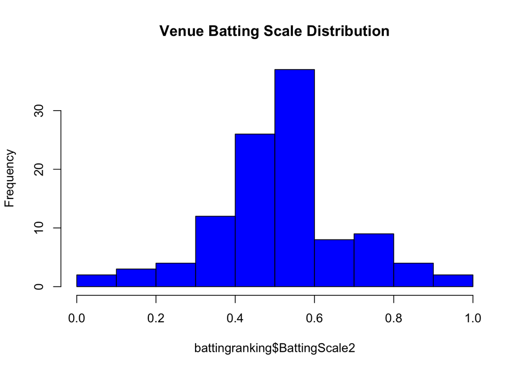

```r
hist(battingranking$BattingScale2, col = "blue", main = "Venue Batting Scale Distribution")
```

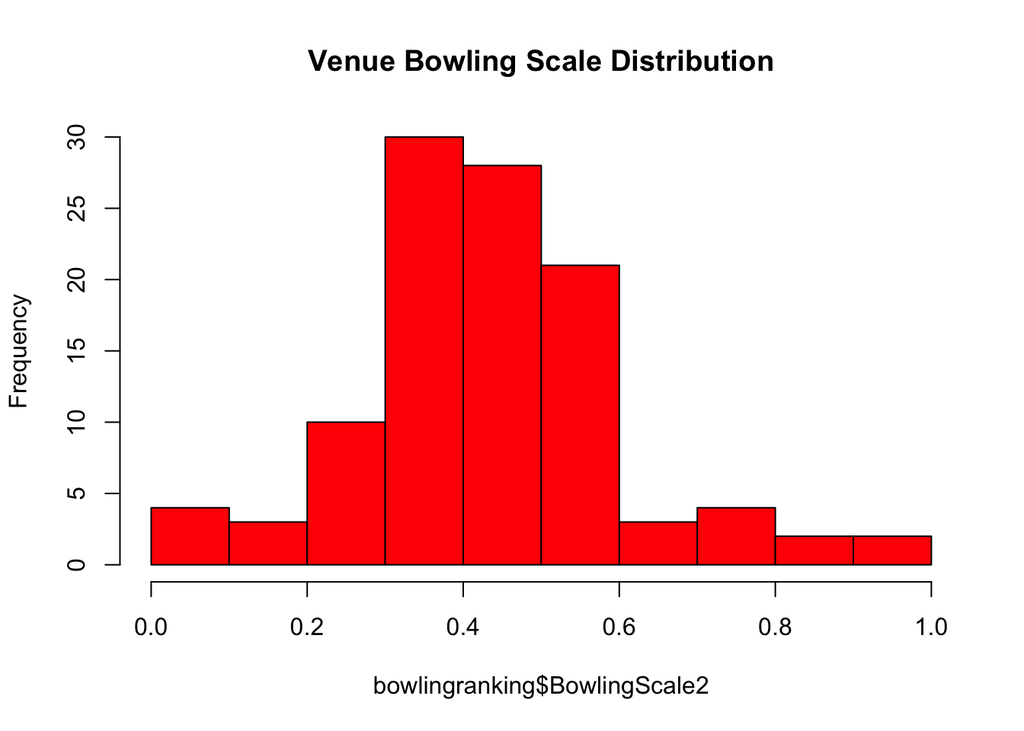

```r
hist(bowlingranking$BowlingScale2, col = "red", main = "Venue Bowling Scale Distribution")
```

Plot Bowling - Batting Impact top 15 for best bowling grounds

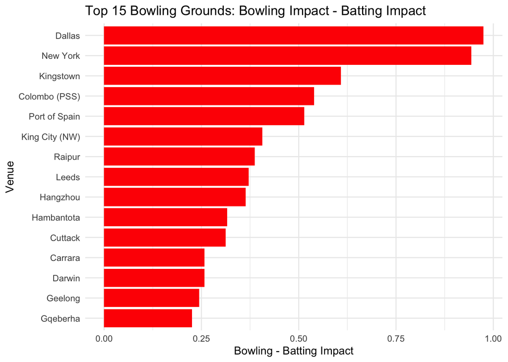

```r
library(ggplot2)
ggplot(bowlingranking[1:15, ], aes(x = reorder(Ground, BowlingScale2 - BattingScale2), y = BowlingScale2 - BattingScale2)) +
  geom_bar(stat = "identity", fill = "red") +
  coord_flip() +
  labs(title = "Top 15 Bowling Grounds: Bowling Impact - Batting Impact",
       x = "Venue",
       y = "Bowling - Batting Impact") +
  theme_minimal()
```

Plot Batting - Bowling Impact top 15 for best batting grounds

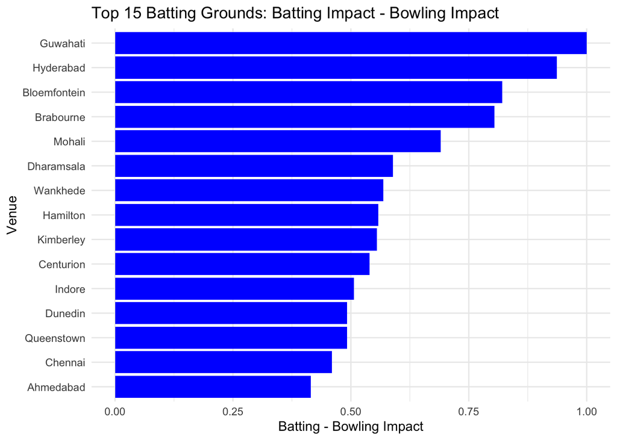

```r
ggplot(battingranking[1:15, ], aes(x = reorder(Ground, BattingScale2 - BowlingScale2), y = BattingScale2 - BowlingScale2)) +
  geom_bar(stat = "identity", fill = "blue") +
  coord_flip() +
  labs(title = "Top 15 Batting Grounds: Batting Impact - Bowling Impact",
       x = "Venue",
       y = "Batting - Bowling Impact") +
  theme_minimal()
```

## Team Ranking

Print ranking of teams

```r
team_ranking <- team_impact %>%
  group_by(Country) %>%
  summarise(TotalImpact = sum(TotalImpact, na.rm = TRUE)) %>%
  arrange(desc(TotalImpact))


team_ranking_recent <- team_impact %>%
  # keep only matches in your recent set
  #filter(ID %in% unique(recent_matches$ID)) %>%
  # join match dates so we can order matches
  left_join(match_data_file_cricinfo %>% select(ID, Date), by = "ID") %>%
  arrange(Country, desc(Date)) %>%
  group_by(Country) %>%
  # keep only the last 15 matches per team
  slice_head(n = 10) %>%
  summarise(
    TotalImpact = mean(TotalImpact, na.rm = TRUE),
    nMatches = n()
  ) %>%
  mutate(TotalImpact_perGame = TotalImpact / nMatches) %>%
  arrange(desc(TotalImpact))

(team_ranking_recent)
```

| Country | TotalImpact | nMatches | TotalImpact_perGame |
| --- | --- | --- | --- |
| IND | 56.23709 | 10 | 5.623709 |
| NZL | 46.79404 | 10 | 4.679404 |
| AUS | 44.36440 | 10 | 4.436440 |
| RSA | 39.28009 | 10 | 3.928009 |
| PAK | 38.36717 | 10 | 3.836717 |
| ENG | 37.13951 | 10 | 3.713951 |
| BAN | 36.92112 | 10 | 3.692112 |
| WI | 36.27321 | 10 | 3.627321 |
| SL | 35.19329 | 10 | 3.519329 |
| AFG | 33.42091 | 10 | 3.342091 |

[output cut: 2 more lines]

Plot team rankings

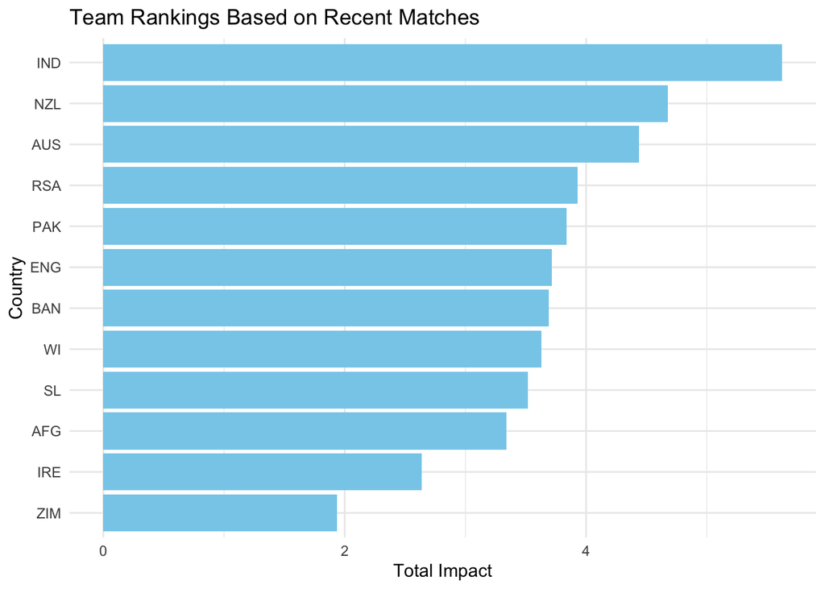

```r
library(ggplot2)
ggplot(team_ranking_recent, aes(x = reorder(Country, TotalImpact_perGame), y = TotalImpact_perGame)) +
  geom_bar(stat = "identity", fill = "skyblue") +
  coord_flip() +
  labs(title = "Team Rankings Based on Recent Matches",
       x = "Country",
       y = "Total Impact") +
  theme_minimal()
```

Get data for Lord’s

```r
battingranking[80,]
```

| Ground | AvgBatImpact | AvgBowlImpact | BattingScale | BowlingScale | BattingScale2 | BowlingScale2 |
| --- | --- | --- | --- | --- | --- | --- |
| Lord's | 1.63872 | 3.255469 | -0.6949896 | 0.4589586 | 0.3983928 | 0.512113 |

# Model Training and Evaluation - Cricket_Prediction.R

## Creating Training Dataset

```r
predcorrectcount = 0
nummatches = nrow(match_data_file_cricinfo)
```

Create data frame for actual impact totals, predicted winner, and actual winner

```r
playertotalimpact = data.frame(Batsman1_T1 = numeric(nummatches),
                               Batsman2_T1 = numeric(nummatches),
                               Batsman3_T1 = numeric(nummatches),
                               Batsman4_T1 = numeric(nummatches),
                               Batsman5_T1 = numeric(nummatches),
                               Batsman6_T1 = numeric(nummatches),
                               Batsman7_T1 = numeric(nummatches),
                               Batsman8_T1 = numeric(nummatches),
                               Bowler1_T1 = numeric(nummatches),
                               Bowler2_T1 = numeric(nummatches),
                               Bowler3_T1 = numeric(nummatches),
                               Bowler4_T1 = numeric(nummatches),
                               Bowler5_T1 = numeric(nummatches),
                               Bowler6_T1 = numeric(nummatches),
                               Batsman1_T2 = numeric(nummatches),
                               Batsman2_T2 = numeric(nummatches),
                               Batsman3_T2 = numeric(nummatches),
                               Batsman4_T2 = numeric(nummatches),
                               Batsman5_T2 = numeric(nummatches),
                               Batsman6_T2 = numeric(nummatches),
                               Batsman7_T2 = numeric(nummatches),
                               Batsman8_T2 = numeric(nummatches),
                               Bowler1_T2 = numeric(nummatches),
                               Bowler2_T2 = numeric(nummatches),
                               Bowler3_T2 = numeric(nummatches),
                               Bowler4_T2 = numeric(nummatches),
                               Bowler5_T2 = numeric(nummatches),
                               Bowler6_T2 = numeric(nummatches),
                               ID = numeric(nummatches))
```

Create match counter

```r
counter = 1
```

Loop through each match in match_data_file_cricinfo and calculate total impact for each player in the playing xi

```r
for(id in match_data_file_cricinfo$ID){
  #get the playing xi from player data
  team1_playingxi = player_data %>% filter(id == ID)
  team1_playingxi = team1_playingxi[1:22,]
  team1_playingxi = team1_playingxi %>% filter(Country == (match_data_file_cricinfo %>% filter(id == ID))[1,1])
  team1_playingxi = team1_playingxi$Player

  team2_playingxi = player_data %>% filter(id == ID)
  team2_playingxi = team2_playingxi[1:22,]
  team2_playingxi = team2_playingxi %>% filter(Country == (match_data_file_cricinfo %>% filter(id == ID))[1,2])
  team2_playingxi = team2_playingxi$Player


  #get the ground buffs
  ground_buffs = venue_factors %>% filter(Ground == (match_data_file_cricinfo %>% filter(id == ID))[1,5])
  #get the player ratings per match for the playing xi
  team1_playingxi_ratings = player_rankings_2 %>% filter(Player %in% team1_playingxi)
  team2_playingxi_ratings = player_rankings_2 %>% filter(Player %in% team2_playingxi)

  #multiply the ground buffs
  #weight it by batter rating, ie if the batter rating is higher, the ground buffs will have more impact
  team1_playingxi_ratings$BatImpactperGame_2 = 0
  team2_playingxi_ratings$BatImpactperGame_2 = 0
  team1_playingxi_ratings$BowlImpactperGame_2 = 0
  team2_playingxi_ratings$BowlImpactperGame_2 = 0

  for(i in 1:nrow(team1_playingxi_ratings)){
    #sort by batting rating
    team1_playingxi_ratings = team1_playingxi_ratings %>% arrange(desc(BatImpactperGame))
    #divide by appropriate factor, assume only 8 batsmen will play
    if(i < 9){
      team1_avg = team1_playingxi_ratings$BatImpactperGame[i] * (1 / median(venue_factors$BattingScale2)) * ground_buffs$BattingScale2[1] * ((9-i)/(10-i))
      team1_playingxi_ratings$BatImpactperGame_2[i] = team1_avg
    }
    else {
      #Bottom batsmen don't get a buff and don't play as much
      team1_avg = 0
      #team1_playingxi_ratings$BatImpactperGame_2[i] = team1_avg
    }

    team1_playingxi_ratings = team1_playingxi_ratings %>% arrange(desc(BowlImpactperGame))
    if(i < 7) {
      team1_avg = team1_playingxi_ratings$BowlImpactperGame[i] * (1 / median(venue_factors$BowlingScale2)) * ground_buffs$BowlingScale2[1] * ((8-i)/(9-i))
      team1_playingxi_ratings$BowlImpactperGame_2[i] = team1_avg
      #team1_playingxi_ratings$BowlImpactperGame_2[i] = team1_avg
    }
    else {
      #Bottom bowlers don't bowl in the game
      team1_playingxi_ratings$BowlImpactperGame_2[i] = 0
    }

  }
  for(i in 1:nrow(team2_playingxi_ratings)){
    team2_playingxi_ratings = team2_playingxi_ratings %>% arrange(desc(BatImpactperGame))
    #divide by appropriate factor, assume only 8 batsmen will play
    if(i < 9){
      team2_avg = team2_playingxi_ratings$BatImpactperGame[i] * (1 / median(venue_factors$BattingScale2)) * ground_buffs$BattingScale2[1] * ((9-i)/(10-i))
      team2_playingxi_ratings$BatImpactperGame_2[i] = team2_avg
    }
    else{
      #Bottom batsmen don't get a buff and don't play as much
      team2_avg = 0
    }

    team2_playingxi_ratings = team2_playingxi_ratings %>% arrange(desc(BowlImpactperGame))
    if(i < 7){
      team2_avg = team2_playingxi_ratings$BowlImpactperGame[i] * (1 / median(venue_factors$BowlingScale2)) * ground_buffs$BowlingScale2[1] * ((8-i)/(9-i))
      team2_playingxi_ratings$BowlImpactperGame_2[i] = team2_avg
    }
    else{
      #Bottom bowlers don't bowl in the game
      team2_playingxi_ratings$BowlImpactperGame_2[i] = 0
    }

  }
  #arrange batting ranking in descending order

  for(j in 1:(ncol(playertotalimpact) / 2)){
    if(j < 9){
      team1_playingxi_ratings = team1_playingxi_ratings %>% arrange(desc(BatImpactperGame))
      playertotalimpact[counter,j] = team1_playingxi_ratings$BatImpactperGame_2[j]
    }
    else{
      team1_playingxi_ratings = team1_playingxi_ratings %>% arrange(desc(BowlImpactperGame))
      playertotalimpact[counter,j] = team1_playingxi_ratings$BowlImpactperGame_2[j-8]
    }

  }
  for(j in 1:(ncol(playertotalimpact) / 2)){
    if(j < 9){
      team2_playingxi_ratings = team2_playingxi_ratings %>% arrange(desc(BatImpactperGame))
      playertotalimpact[counter,(j + 14)] = team2_playingxi_ratings$BatImpactperGame_2[j]
    }
    else{
      team2_playingxi_ratings = team2_playingxi_ratings %>% arrange(desc(BowlImpactperGame))
      playertotalimpact[counter,(j + 14)] = team2_playingxi_ratings$BowlImpactperGame_2[j-8]
    }
  }
  playertotalimpact[counter, 29] = id

  counter = counter + 1
}
```

Join by id to match_data_cricinfo$Winner_Team1

```r
playertotalimpact2 = right_join(playertotalimpact, match_data_file_cricinfo, by = "ID")
```

Remove all columns from match_data_cricinfo except Winner_Team1

```r
playertotalimpact2 = playertotalimpact2 %>% dplyr::select(-c(30:44))
playertotalimpact2 = playertotalimpact2 %>% dplyr::select(-c(29))
```

Find nas

```r
nas = apply(playertotalimpact2, 2, function(x) sum(is.na(x)))
```

Any cell with gets row removed

```r
playertotalimpact2 = playertotalimpact2 %>% filter_all(all_vars(!is.na(.)))
```

## Heuristic: If Team 1 has greater total impact, predict Team 1 wins, else Team 2 wins

```r
predcorrectcount = 0
team1vec = numeric(nrow(playertotalimpact2))
team2vec = numeric(nrow(playertotalimpact2))
nummatches = nrow(playertotalimpact2)
for(i in 1:nrow(playertotalimpact2)){
  #sum rows one through 17
  team1_total = sum(playertotalimpact2[i, 1:14])
  team2_total = sum(playertotalimpact2[i, 15:28])
  team1vec[i] = team1_total
  team2vec[i] = team2_total
  if(team1_total > team2_total){
    predicted_winner = 1
  }
  else{
    predicted_winner = 0
  }
  if(predicted_winner == as.numeric(playertotalimpact2$Winner_Team1[i])){
    predcorrectcount = predcorrectcount + 1
  }
}
accuracy = predcorrectcount / nummatches
print(paste("Heuristic Accuracy on all matches:", round(accuracy * 100, 2), "%"))
```

```
## [1] "Heuristic Accuracy on all matches: 65.98 %"
```

## Logistic Regression with repeated splits

```r
target = factor(playertotalimpact2$Winner_Team1, levels = c(0, 1), labels = c("Team2", "Team1"))

accvector = numeric(30)  # store accuracies
set.seed(314)
overallbestlambda = 0
overallbestalpha = 0
for(i in 1:30){

  # Train-test split (80-20)
  train_index <- createDataPartition(playertotalimpact2$Winner_Team1, p = 0.8, list = FALSE)
  train_data <- playertotalimpact2[train_index, ]
  test_data  <- playertotalimpact2[-train_index, ]

  # Define Predictors and Target
  train_x <- as.matrix(train_data[, 1:28])
  train_y <- as.factor(train_data$Winner_Team1)  # 0/1
  test_x  <- as.matrix(test_data[, 1:28])
  test_y  <- as.factor(test_data$Winner_Team1)   # 0/1

  # Hyperparameter grid search
  grid <- expand.grid(alpha = seq(0, 1, by = 0.1), lambda = seq(0.001, 0.1, by = 0.001))

  logistic_model <- train(
    x = train_x,
    y = train_y,
    method = "glmnet",
    trControl = trainControl(method = "cv", number = 5),
    family = "binomial",
    metric = "Accuracy",
    tuneGrid = grid
  )

  best_lambda <- logistic_model$bestTune$lambda
  best_alpha <- logistic_model$bestTune$alpha
  print(paste("Best Lambda:", round(best_lambda, 4), "Best Alpha:", round(best_alpha, 4)))

  # Train logistic model with best parameters
  best_log_model <- glmnet(
    x = train_x,
    y = as.numeric(train_y) - 1,
    family = "binomial",
    alpha = best_alpha,
    lambda = best_lambda
  )

  # Get test set probabilities
  test_prob <- predict(best_log_model, newx = test_x, type = "response", s = best_lambda)

  # Cross-validation to determine the best threshold
  thresholds = numeric(10)
  folds <- createFolds(train_y, k = 10, list = TRUE)


  # Apply threshold to test predictions
  test_predictions <- factor(ifelse(test_prob > 0.5, 1, 0),
                             levels = c(0, 1),
                             labels = c("Team2", "Team1"))

  test_y <- factor(test_y, levels = c(0, 1), labels = c("Team2", "Team1"))

  # Compute Accuracy
  conf_matrix <- confusionMatrix(test_predictions, test_y)
  accvector[i] <- conf_matrix$overall['Accuracy']
  print(accvector[i])
  if(i == 1){
    overallbestlambda = best_lambda
    overallbestalpha = best_alpha
  }
  else{
    if(conf_matrix$overall['Accuracy'] > max(accvector[1:(i-1)])){
      overallbestlambda = best_lambda
      overallbestalpha = best_alpha
    }
  }

}
```

```
## [1] "Best Lambda: 0.044 Best Alpha: 0.2"
## [1] 0.6603774
## [1] "Best Lambda: 0.099 Best Alpha: 0.1"
## [1] 0.6509434
## [1] "Best Lambda: 0.05 Best Alpha: 0"
## [1] 0.6509434
## [1] "Best Lambda: 0.001 Best Alpha: 0.2"
## [1] 0.6179245
## [1] "Best Lambda: 0.014 Best Alpha: 1"
## [1] 0.6320755
## [1] "Best Lambda: 0.1 Best Alpha: 0"
## [1] 0.7169811
## [1] "Best Lambda: 0.099 Best Alpha: 0"
## [1] 0.6462264
## [1] "Best Lambda: 0.013 Best Alpha: 0"
```

[output cut: 45 more lines]

Train the final Logistic Regression model on the entire dataset

```r
set.seed(314)  # For reproducibility
train_index <- createDataPartition(target, p = 0.8, list = FALSE)
train_data <- playertotalimpact2[train_index, ]
test_data  <- playertotalimpact2[-train_index, ]
```

Define Predictors and Target for the final model

```r
predictors <- as.matrix(train_data[, 1:28])  # Player impact features
target <- as.factor(train_data$Winner_Team1)  # Target variable (0 or 1)
```

Hyperparameter for final model selected based on grid search

```r
final_model = glmnet(
  x = playertotalimpact2[, 1:28], # Player impact features,
  y = playertotalimpact2[,29], # Convert factor (0/1) to numeric
  family = "binomial",
  alpha = overallbestalpha,  # Use the best alpha from previous model
  lambda = overallbestlambda, # Use the best lambda from previous model
)

print(paste("Accuracy value on test set: ", round(max(accvector) * 100, 2), "%"))
```

```
## [1] "Accuracy value on test set:  72.64 %"
```

## RF model

```r
set.seed(314)  # For reproducibility
```

Train-test split (80-20)

```r
accvec_rf = numeric(30)  # Initialize accuracy vector for 30 iterations
for(i in 1:30) {  # Repeat for 30 iterations to get a robust accuracy
  train_index_rf <- createDataPartition(playertotalimpact2$Winner_Team1, p = 0.8, list = FALSE)
  train_data_rf <- playertotalimpact2[train_index_rf, ]
  test_data_rf  <- playertotalimpact2[-train_index_rf, ]
  # Define Predictors and Target for RF model
  train_x_rf <- train_data_rf[, 1:28]  # Player impact features
  train_y_rf <- as.factor(train_data_rf$Winner_Team1)  # Target variable (0 or 1)
  test_x_rf  <- test_data_rf[, 1:28]
  test_y_rf  <- as.factor(test_data_rf$Winner_Team1)  # Target variable (0 or 1)
  # Train the Random Forest model
  rf_model <- train(
    x = train_x_rf,
    y = train_y_rf,
    method = "rf",
    trControl = trainControl(method = "cv", number = 5),
    tuneLength = 5,  # Number of different mtry values to try
    ntree = 500,  # Number of trees
    importance = TRUE
  )
  # Get accuracy
  rf_predictions <- predict(rf_model, newdata = test_x_rf)
  # Compute Accuracy
  rf_conf_matrix <- confusionMatrix(rf_predictions, test_y_rf)
  rf_accuracy <- rf_conf_matrix$overall['Accuracy']
  print(paste("Random Forest Model Accuracy on Test Set: ", round(rf_accuracy * 100, 2), "%"))
  accvec_rf[i] <- rf_accuracy  # Store accuracy for each iteration
}
```

```
## [1] "Random Forest Model Accuracy on Test Set:  66.51 %"
## [1] "Random Forest Model Accuracy on Test Set:  64.62 %"
## [1] "Random Forest Model Accuracy on Test Set:  60.85 %"
## [1] "Random Forest Model Accuracy on Test Set:  60.85 %"
## [1] "Random Forest Model Accuracy on Test Set:  66.51 %"
## [1] "Random Forest Model Accuracy on Test Set:  60.38 %"
## [1] "Random Forest Model Accuracy on Test Set:  67.92 %"
## [1] "Random Forest Model Accuracy on Test Set:  65.57 %"
## [1] "Random Forest Model Accuracy on Test Set:  67.45 %"
## [1] "Random Forest Model Accuracy on Test Set:  65.09 %"
## [1] "Random Forest Model Accuracy on Test Set:  64.15 %"
## [1] "Random Forest Model Accuracy on Test Set:  69.34 %"
## [1] "Random Forest Model Accuracy on Test Set:  67.45 %"
## [1] "Random Forest Model Accuracy on Test Set:  68.4 %"
## [1] "Random Forest Model Accuracy on Test Set:  65.57 %"
## [1] "Random Forest Model Accuracy on Test Set:  56.6 %"
## [1] "Random Forest Model Accuracy on Test Set:  58.49 %"
## [1] "Random Forest Model Accuracy on Test Set:  64.15 %"
## [1] "Random Forest Model Accuracy on Test Set:  66.98 %"
## [1] "Random Forest Model Accuracy on Test Set:  61.32 %"
## [1] "Random Forest Model Accuracy on Test Set:  66.51 %"
## [1] "Random Forest Model Accuracy on Test Set:  65.57 %"
## [1] "Random Forest Model Accuracy on Test Set:  70.28 %"
## [1] "Random Forest Model Accuracy on Test Set:  65.57 %"
## [1] "Random Forest Model Accuracy on Test Set:  63.21 %"
## [1] "Random Forest Model Accuracy on Test Set:  66.04 %"
## [1] "Random Forest Model Accuracy on Test Set:  65.57 %"
## [1] "Random Forest Model Accuracy on Test Set:  66.51 %"
## [1] "Random Forest Model Accuracy on Test Set:  70.28 %"
## [1] "Random Forest Model Accuracy on Test Set:  63.68 %"
```

```r
# Maximum: 70.28
max(accvec_rf) # Print the maximum accuracy from the 30 iterations
```

```
## [1] 0.7028302
```

## SVMs

```r
library(e1071)
set.seed(314)  # For reproducibility
accvec_svm = numeric(30)  # Initialize accuracy vector for 30 iterations
for(i in 1:30) {  # Repeat for 30 iterations to get a robust accuracy
  train_index_svm <- createDataPartition(playertotalimpact2$Winner_Team1, p = 0.8, list = FALSE)
  train_data_svm <- playertotalimpact2[train_index_svm, ]
  test_data_svm  <- playertotalimpact2[-train_index_svm, ]

  # Define Predictors and Target for SVM model
  train_x_svm <- train_data_svm[, 1:28]  # Player impact features
  train_y_svm <- as.factor(train_data_svm$Winner_Team1)  # Target variable (0 or 1)
  test_x_svm  <- test_data_svm[, 1:28]
  test_y_svm  <- as.factor(test_data_svm$Winner_Team1)  # Target variable (0 or 1)

  # Train the SVM model
  grid_svm <- expand.grid(C = 2^(-5:5))  # Hyperparameter grid for SVM
  svm_model <- train(
    x = train_x_svm,
    y = train_y_svm,
    method = "svmLinear",
    trControl = trainControl(method = "cv", number = 5),
    tunegrid = grid_svm,
  )

  # Get accuracy
  svm_predictions <- predict(svm_model, newdata = test_x_svm)

  # Compute Accuracy
  svm_conf_matrix <- confusionMatrix(svm_predictions, test_y_svm)
  svm_accuracy <- svm_conf_matrix$overall['Accuracy']

  print(paste("SVM Model Accuracy on Test Set: ", round(svm_accuracy * 100, 2), "%"))

  accvec_svm[i] <- svm_accuracy  # Store accuracy for each iteration
}
```

```
## [1] "SVM Model Accuracy on Test Set:  63.68 %"
## [1] "SVM Model Accuracy on Test Set:  62.26 %"
## [1] "SVM Model Accuracy on Test Set:  68.87 %"
## [1] "SVM Model Accuracy on Test Set:  67.45 %"
## [1] "SVM Model Accuracy on Test Set:  67.45 %"
## [1] "SVM Model Accuracy on Test Set:  61.79 %"
## [1] "SVM Model Accuracy on Test Set:  64.62 %"
## [1] "SVM Model Accuracy on Test Set:  67.45 %"
## [1] "SVM Model Accuracy on Test Set:  67.45 %"
## [1] "SVM Model Accuracy on Test Set:  62.74 %"
## [1] "SVM Model Accuracy on Test Set:  65.09 %"
## [1] "SVM Model Accuracy on Test Set:  67.92 %"
## [1] "SVM Model Accuracy on Test Set:  66.51 %"
## [1] "SVM Model Accuracy on Test Set:  66.51 %"
## [1] "SVM Model Accuracy on Test Set:  64.15 %"
## [1] "SVM Model Accuracy on Test Set:  67.45 %"
## [1] "SVM Model Accuracy on Test Set:  69.34 %"
## [1] "SVM Model Accuracy on Test Set:  64.15 %"
## [1] "SVM Model Accuracy on Test Set:  66.04 %"
## [1] "SVM Model Accuracy on Test Set:  63.21 %"
## [1] "SVM Model Accuracy on Test Set:  66.98 %"
## [1] "SVM Model Accuracy on Test Set:  62.26 %"
## [1] "SVM Model Accuracy on Test Set:  61.32 %"
## [1] "SVM Model Accuracy on Test Set:  57.55 %"
## [1] "SVM Model Accuracy on Test Set:  69.34 %"
## [1] "SVM Model Accuracy on Test Set:  70.75 %"
## [1] "SVM Model Accuracy on Test Set:  66.98 %"
## [1] "SVM Model Accuracy on Test Set:  66.04 %"
## [1] "SVM Model Accuracy on Test Set:  70.75 %"
## [1] "SVM Model Accuracy on Test Set:  69.81 %"
```

```r
# Maximum: 70.75
max(accvec_svm) # Print the maximum accuracy from the 30 iterations
```

```
## [1] 0.7075472
```

## Model Comparison

```r
model_accuracies <- data.frame(
  Model = c("Logistic Regression", "Random Forest", "SVM", "Heuristic"),
  Accuracy = c(max(accvector) * 100, max(accvec_rf) * 100, max(accvec_svm) * 100, accuracy * 100),
  CI_Lower = c(
    max(accvector) * 100 - 1.96 * (sd(accvector) * 100 / sqrt(30)),
    max(accvec_rf) * 100 - 1.96 * (sd(accvec_rf) * 100 / sqrt(30)),
    max(accvec_svm) * 100 - 1.96 * (sd(accvec_svm) * 100 / sqrt(30)),
    accuracy * 100 - 1.96 * (sqrt((accuracy * (1 - accuracy)) / nrow(playertotalimpact2)) * 100)
  ),
  CI_Upper = c(
    max(accvector) * 100 + 1.96 * (sd(accvector) * 100 / sqrt(30)),
    max(accvec_rf) * 100 + 1.96 * (sd(accvec_rf) * 100 / sqrt(30)),
    max(accvec_svm) * 100 + 1.96 * (sd(accvec_svm) * 100 / sqrt(30)),
    accuracy * 100 + 1.96 * (sqrt((accuracy * (1 - accuracy)) / nrow(playertotalimpact2)) * 100)
  )
)
print(model_accuracies)
```

```
##                 Model Accuracy CI_Lower CI_Upper
## 1 Logistic Regression 72.64151 71.50172 73.78130
## 2       Random Forest 70.28302 69.11076 71.45528
## 3                 SVM 70.75472 69.64521 71.86422
## 4           Heuristic 65.97549 63.12457 68.82642
```

# Model Evaluation (Human Eye Check) on Real Games - T20_Final_Example.R

## Example Match: India vs South Africa, T20 World Cup Final 2024 at Bridgetown

Get the playing XI for both teams

```r
team1_playingxi = player_data %>% filter(ID == 2729)
team1_playingxi = team1_playingxi[1:22,]
team1_playingxi = team1_playingxi %>% filter(Country == "IND")
team1_playingxi = team1_playingxi$Player

team2_playingxi = player_data %>% filter(ID == 2729)
team2_playingxi = team2_playingxi[1:22,]
team2_playingxi = team2_playingxi %>% filter(Country == "RSA")
team2_playingxi = team2_playingxi$Player
```

Get the ground buffs

```r
ground_buffs = venue_factors %>% filter(Ground == "Bridgetown")
```

Get the player ratings per match for the playing xi

```r
team1_playingxi_ratings = player_rankings_2 %>% filter(Player %in% team1_playingxi)
team2_playingxi_ratings = player_rankings_2 %>% filter(Player %in% team2_playingxi)
```

Multiply the ground buffs Weight it by batter rating, ie if the batter rating is higher, the ground buffs will have more impact

```r
team1_playingxi_ratings$BatImpactperGame_2 = 0
team2_playingxi_ratings$BatImpactperGame_2 = 0
team1_playingxi_ratings$BowlImpactperGame_2 = 0
team2_playingxi_ratings$BowlImpactperGame_2 = 0
```

Evaluate player performance in Team 1 according to their ratings and ground conditions

```r
for(i in 1:nrow(team1_playingxi_ratings)){
  # Sort by batting rating
  team1_playingxi_ratings = team1_playingxi_ratings %>% arrange(desc(BatImpactperGame))
  # Divide by appropriate factor, assume only 8 batsmen will play
  if(i < 9){
    team1_avg = team1_playingxi_ratings$BatImpactperGame[i] * (1 / median(venue_factors$BattingScale2)) * ground_buffs$BattingScale2[1] * ((9-i)/(10-i))
    team1_playingxi_ratings$BatImpactperGame_2[i] = team1_avg
  }
  else {
    # Bottom batsmen don't get a buff and don't play as much
    team1_avg = team1_playingxi_ratings$BatImpactperGame[i] / 5
    team1_playingxi_ratings$BatImpactperGame_2[i] = team1_avg
  }

  team1_playingxi_ratings = team1_playingxi_ratings %>% arrange(desc(BowlImpactperGame))
  if(i < 7) {
    team1_avg = team1_playingxi_ratings$BowlImpactperGame[i] * (1 / median(venue_factors$BowlingScale2)) * ground_buffs$BowlingScale2[1] * ((8-i)/(9-i))
    team1_playingxi_ratings$BowlImpactperGame_2[i] = team1_avg
  }
  else {
    # Bottom bowlers don't bowl in the game
    team1_playingxi_ratings$BowlImpactperGame_2[i] = 0
  }

}
```

Evaluate player performance in Team 2 according to their ratings and ground conditions

```r
for(i in 1:nrow(team2_playingxi_ratings)){
  team2_playingxi_ratings = team2_playingxi_ratings %>% arrange(desc(BatImpactperGame))
  # Divide by appropriate factor, assume only 8 batsmen will play
  if(i < 9){
    team2_avg = team2_playingxi_ratings$BatImpactperGame[i] * (1 / median(venue_factors$BattingScale2)) * ground_buffs$BattingScale2[1] * ((9-i)/(10-i))
    team2_playingxi_ratings$BatImpactperGame_2[i] = team2_avg
  }
  else{
    # Bottom batsmen don't get a buff and don't play as much
    team2_avg = team2_playingxi_ratings$BatImpactperGame[i] / 5
    team2_playingxi_ratings$BatImpactperGame_2[i] = team2_avg
  }

  team2_playingxi_ratings = team2_playingxi_ratings %>% arrange(desc(BowlImpactperGame))
  if(i < 7){
    team2_avg = team2_playingxi_ratings$BowlImpactperGame[i] * (1 / median(venue_factors$BowlingScale2)) * ground_buffs$BowlingScale2[1] * ((8-i)/(9-i))
    team2_playingxi_ratings$BowlImpactperGame_2[i] = team2_avg
  }
  else{
    # Bottom bowlers don't bowl in the game
    team2_playingxi_ratings$BowlImpactperGame_2[i] = 0
  }

}
```

Rearrange data to make sure 11 batting rankings correct

```r
team1_batting = (team1_playingxi_ratings %>% arrange(desc(BatImpactperGame_2)))$BatImpactperGame_2
team2_batting = (team2_playingxi_ratings %>% arrange(desc(BatImpactperGame_2)))$BatImpactperGame_2
team1_bowling = (team1_playingxi_ratings %>% arrange(desc(BowlImpactperGame_2)))$BowlImpactperGame_2
team2_bowling = (team2_playingxi_ratings %>% arrange(desc(BowlImpactperGame_2)))$BowlImpactperGame_2
```

Calculate win probability

```r
ind_winprob = predict(final_model, newx = (data.frame(Batsman1_T1 = team1_batting[1],
                                    Batsman2_T1 = team1_batting[2],
                                    Batsman3_T1 = team1_batting[3],
                                    Batsman4_T1 = team1_batting[4],
                                    Batsman5_T1 = team1_batting[5],
                                    Batsman6_T1 = team1_batting[6],
                                    Batsman7_T1 = team1_batting[7],
                                    Batsman8_T1 = team1_batting[8],
                                    Bowler1_T1 = team1_bowling[1],
                                    Bowler2_T1 = team1_bowling[2],
                                    Bowler3_T1 = team1_bowling[3],
                                    Bowler4_T1 = team1_bowling[4],
                                    Bowler5_T1 = team1_bowling[5],
                                    Bowler6_T1 = team1_bowling[6],
                                    Batsman1_T2 = team2_batting[1],
                                    Batsman2_T2 = team2_batting[2],
                                    Batsman3_T2 = team2_batting[3],
                                    Batsman4_T2 = team2_batting[4],
                                    Batsman5_T2 = team2_batting[5],
                                    Batsman6_T2 = team2_batting[6],
                                    Batsman7_T2 = team2_batting[7],
                                    Batsman8_T2 = team2_batting[8],
                                    Bowler1_T2 = team2_bowling[1],
                                    Bowler2_T2 = team2_bowling[2],
                                    Bowler3_T2 = team2_bowling[3],
                                    Bowler4_T2 = team2_bowling[4],
                                    Bowler5_T2 = team2_bowling[5],
                                    Bowler6_T2 = team2_bowling[6]))
                                    , type = "response")
ind_winprob = ind_winprob
print(paste("India win probability: ", round(ind_winprob, 4) * 100, "%"))
```

```
## [1] "India win probability:  55.34 %"
```

```r
rsa_winprob = 1 - ind_winprob
print(paste("South Africa win probability: ", round(rsa_winprob, 4) * 100, "%"))
```

```
## [1] "South Africa win probability:  44.66 %"
```

## With random effect correction based on number of matches played

Predict the T20 World Cup Final 2024 with random effect as well, or any game you’d like

Select games that can be passed into model with easy access; check Match_Data-Cricinfo file for more:

**IND vs SL, 2014 T20 WC final** (SL won by 6 wickets, Mirpur) Match ID 400

**AFG vs WI, 2016 T20 WC match** (AFG won by 6 runs, Nagpur) Match ID 552

**AUS vs NZL, 2021 T20 WC final** (AUS won by 8 wickets, Dubai (DICS)) Match ID 1428

**ENG vs PAK, 2022 T20 WC final** (ENG won by 5 wickets, Melbourne) Match ID 1879

**IND vs PAK, 2024 T20 WC match** (IND won by 6 runs, New York) Match ID 2658 - This example, the model got wrong

Most recent T20I: **AUS vs RSA at Cairns** (AUS won by 2 wickets, August 16 2025) Match ID 3407

```r
country1 = "AUS"
country2 = "RSA"
Venue = "Cairns"
MatchID = 3407

team1_playingxi = player_data %>% filter(ID == MatchID)
team1_playingxi = team1_playingxi[1:22,]
team1_playingxi = team1_playingxi %>% filter(Country == country1)
team1_playingxi = team1_playingxi$Player

team2_playingxi = player_data %>% filter(ID == MatchID)
team2_playingxi = team2_playingxi[1:22,]
team2_playingxi = team2_playingxi %>% filter(Country == country2)
team2_playingxi = team2_playingxi$Player
```

Get the ground buffs and the player ratings per match for the playing xi

```r
ground_buffs = venue_factors %>% filter(Ground == Venue)
team1_playingxi_ratings = player_rankings_2 %>% filter(Player %in% team1_playingxi)
team2_playingxi_ratings = player_rankings_2 %>% filter(Player %in% team2_playingxi)
```

Multiply the ground buffs Weight it by batter rating, ie if the batter rating is higher, the ground buffs will have more impact

```r
team1_playingxi_ratings$BatImpactperGame_2 = 0
team2_playingxi_ratings$BatImpactperGame_2 = 0
team1_playingxi_ratings$BowlImpactperGame_2 = 0
team2_playingxi_ratings$BowlImpactperGame_2 = 0
```

Simulate 20 times to get a better idea of win probability with random effects

```r
kvec = numeric(20)
for(k in 1:20){
  for(i in 1:nrow(team1_playingxi_ratings)){
    #sort by batting rating
    team1_playingxi_ratings = team1_playingxi_ratings %>% arrange(desc(BatImpactperGame))
    #divide by appropriate factor, assume only 8 batsmen will play
    if(i < 9){
      team1_avg = team1_playingxi_ratings$BatImpactperGame[i] * (1 / median(venue_factors$BattingScale2)) * ground_buffs$BattingScale2[1] * ((9-i)/(10-i))
      team1_playingxi_ratings$BatImpactperGame_2[i] = rnorm(1, team1_avg, abs(team1_avg / team1_playingxi_ratings$MatchesPlayed[i])) # Random process
    }
    else {
      #Bottom batsmen don't get a buff and don't play as much
      team1_avg = team1_playingxi_ratings$BatImpactperGame[i] / 5
      team1_playingxi_ratings$BatImpactperGame_2[i] = rnorm(1, team1_avg, abs(team1_avg / team1_playingxi_ratings$MatchesPlayed[i])) # Random process
      #team1_playingxi_ratings$BatImpactperGame_2[i] = team1_avg
    }

    team1_playingxi_ratings = team1_playingxi_ratings %>% arrange(desc(BowlImpactperGame))
    if(i < 7) {
      team1_avg = team1_playingxi_ratings$BowlImpactperGame[i] * (1 / median(venue_factors$BowlingScale2)) * ground_buffs$BowlingScale2[1] * ((8-i)/(9-i))
      team1_playingxi_ratings$BowlImpactperGame_2[i] = rnorm(1, team1_avg, abs(team1_avg / team1_playingxi_ratings$MatchesPlayed[i])) # Random process
      #team1_playingxi_ratings$BowlImpactperGame_2[i] = team1_avg
    }
    else {
      #Bottom bowlers don't bowl in the game
      team1_playingxi_ratings$BowlImpactperGame_2[i] = 0
    }

  }
  for(i in 1:nrow(team2_playingxi_ratings)){
    team2_playingxi_ratings = team2_playingxi_ratings %>% arrange(desc(BatImpactperGame))
    #divide by appropriate factor, assume only 8 batsmen will play
    if(i < 9){
      team2_avg = team2_playingxi_ratings$BatImpactperGame[i] * (1 / median(venue_factors$BattingScale2)) * ground_buffs$BattingScale2[1] * ((9-i)/(10-i))
      team2_playingxi_ratings$BatImpactperGame_2[i] = rnorm(1, team2_avg, abs(team2_avg / team2_playingxi_ratings$MatchesPlayed[i])) # Random process
    }
    else{
      #Bottom batsmen don't get a buff and don't play as much
      team2_avg = team2_playingxi_ratings$BatImpactperGame[i] / 5
      team2_playingxi_ratings$BatImpactperGame_2[i] = rnorm(1, team2_avg, abs(team2_avg / team2_playingxi_ratings$MatchesPlayed[i])) # Random process
    }

    team2_playingxi_ratings = team2_playingxi_ratings %>% arrange(desc(BowlImpactperGame))
    if(i < 7){
      team2_avg = team2_playingxi_ratings$BowlImpactperGame[i] * (1 / median(venue_factors$BowlingScale2)) * ground_buffs$BowlingScale2[1] * ((8-i)/(9-i))
      team2_playingxi_ratings$BowlImpactperGame_2[i] = rnorm(1, team2_avg, abs(team2_avg / team2_playingxi_ratings$MatchesPlayed[i])) # Random process
    }
    else{
      #Bottom bowlers don't bowl in the game
      team2_playingxi_ratings$BowlImpactperGame_2[i] = 0
    }


}
# Rearrange data to make sure 11 batting rankings correct
team1_batting = (team1_playingxi_ratings %>% arrange(desc(BatImpactperGame_2)))$BatImpactperGame_2
team2_batting = (team2_playingxi_ratings %>% arrange(desc(BatImpactperGame_2)))$BatImpactperGame_2
team1_bowling = (team1_playingxi_ratings %>% arrange(desc(BowlImpactperGame_2)))$BowlImpactperGame_2
team2_bowling = (team2_playingxi_ratings %>% arrange(desc(BowlImpactperGame_2)))$BowlImpactperGame_2

winprob = predict(final_model, newx = (data.frame(Batsman1_T1 = team1_batting[1],
                                                      Batsman2_T1 = team1_batting[2],
                                                      Batsman3_T1 = team1_batting[3],
                                                      Batsman4_T1 = team1_batting[4],
                                                      Batsman5_T1 = team1_batting[5],
                                                      Batsman6_T1 = team1_batting[6],
                                                      Batsman7_T1 = team1_batting[7],
                                                      Batsman8_T1 = team1_batting[8],
                                                      Bowler1_T1 = team1_bowling[1],
                                                      Bowler2_T1 = team1_bowling[2],
                                                      Bowler3_T1 = team1_bowling[3],
                                                      Bowler4_T1 = team1_bowling[4],
                                                      Bowler5_T1 = team1_bowling[5],
                                                      Bowler6_T1 = team1_bowling[6],
                                                      Batsman1_T2 = team2_batting[1],
                                                      Batsman2_T2 = team2_batting[2],
                                                      Batsman3_T2 = team2_batting[3],
                                                      Batsman4_T2 = team2_batting[4],
                                                      Batsman5_T2 = team2_batting[5],
                                                      Batsman6_T2 = team2_batting[6],
                                                      Batsman7_T2 = team2_batting[7],
                                                      Batsman8_T2 = team2_batting[8],
                                                      Bowler1_T2 = team2_bowling[1],
                                                      Bowler2_T2 = team2_bowling[2],
                                                      Bowler3_T2 = team2_bowling[3],
                                                      Bowler4_T2 = team2_bowling[4],
                                                      Bowler5_T2 = team2_bowling[5],
                                                      Bowler6_T2 = team2_bowling[6]))
                      , type = "response")
 kvec[k] = winprob
}
kvec = kvec
print(paste(country1, "win probability: ", round(mean(kvec), 4) * 100, "%"))
```

```
## [1] "AUS win probability:  67.12 %"
```

```r
print(paste(country2, "win probability: ", round((1 - mean(kvec)), 4) * 100, "%"))
```

```
## [1] "RSA win probability:  32.88 %"
```

# Web App for Predicting Games and Player Impact - App.R (located in Shiny_App code folder)

The app is available at: https://archithsharma.shinyapps.io/Cricket-Analyzer/, with three tools:

- Player Comparison Tool
- Past Match Model Output
- Predict Future Match based on Playing XI

## Player Comparison Tool

The player comparison tool will compare two players based on their batting and bowling impact per game. For all-rounders, it will show the value relative to all-rounders for bowling and batting as well.

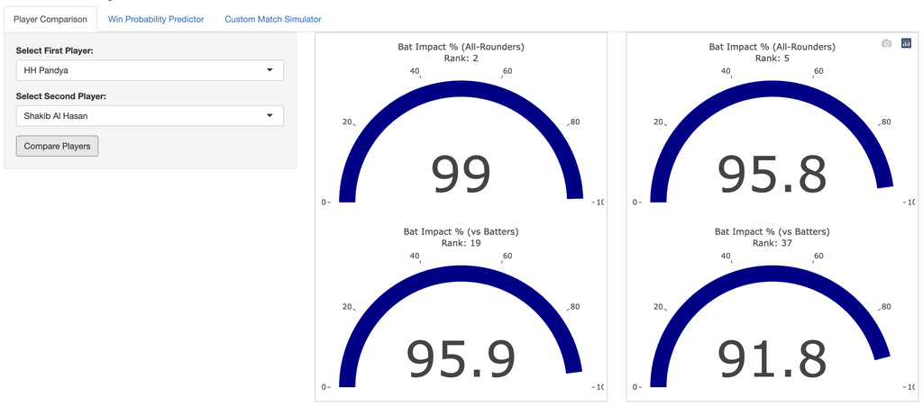

Comparison between Hardik Pandya & Shakib al Hasan

## Past Match Model Output

The past match model output will show the player impact for both teams in a past match, and the predicted winner based on the logistic regression model.

[figure not shown]

Past Match Model Output  
IND vs RSA, T20 WC Final 2024

## Predict Future Match based on Playing XI

The predict future match based on playing XI will allow the user to select a playing XI for two teams (any player), and the venue. The model will then predict the win probability for both teams based on the logistic regression model.

An example was tested for the most recent T20I match between Afghanistan and Pakistan. The model’s most recent data update was on August 16, 2025, and the match was played on August 29, 2025. The model predicted a 60% win probability for Pakistan, who went on to win the match by 39 runs, further legitimizing the model.

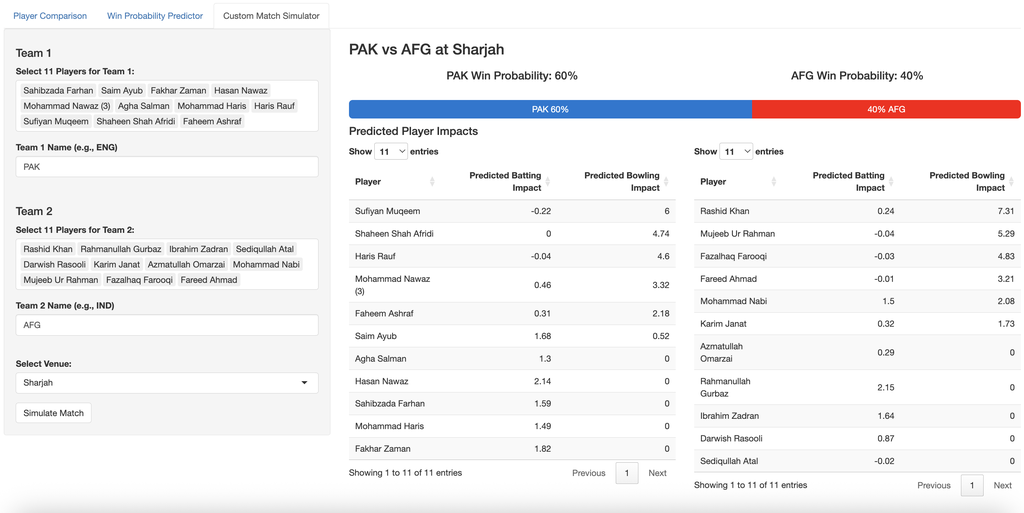

Predict Future Match based on Playing XI for AFG vs PAK, T20I, August 29 2025

The code for the app is located in the Shiny_App folder, in the App.R file. All other code is included in the markdown file or available on github, in https://github.com/ArchithSharma/CricketPredictions/.